# IPL AUCTION

# kdeplot(Kernel distribution estimation plot) of Increase Percentage:

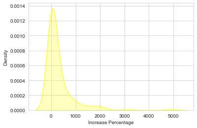

```python
sns.kdeplot(IPL2["Increase Percentage"],color="yellow",shade=True)
plt.show()
```

# kdeplot(Kernel distribution estimation plot) of Increase Percentage and Base Price :

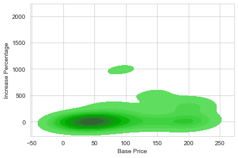

```python
sns.kdeplot(IPL2["Base Price"],IPL3["Increase Percentage"],color="green",shade=True)
plt.show()
```

# Swarm plot of Increase Percentage and 2021 Team:

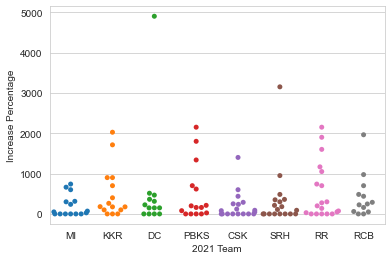

```python
sns.swarmplot(x="2021 Team",y="Increase Percentage",data=IPL2)
plt.show()
```

# Heat Map:

```python
IPL2.corr()
```

|  | Set No. | Age | IPL | Base Price | Increase Percentage |
| --- | --- | --- | --- | --- | --- |
| Set No. | 1.000000 | -0.217646 | -0.392722 | -0.533670 | -0.274668 |
| Age | -0.217646 | 1.000000 | 0.463484 | 0.436103 | -0.164773 |
| IPL | -0.392722 | 0.463484 | 1.000000 | 0.511262 | -0.040509 |
| Base Price | -0.533670 | 0.436103 | 0.511262 | 1.000000 | -0.086065 |
| Increase Percentage | -0.274668 | -0.164773 | -0.040509 | -0.086065 | 1.000000 |

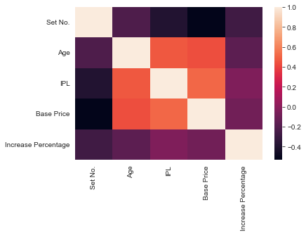

```python
sns.heatmap(IPL2.corr())
plt.show()
```

# Conclusion

204 players were sold and INR 5,51,70,00,000 was splurged amongst the ten franchises during the two-day TATA Indian Premier League (IPL) 2022 Auction in Bengaluru.Young Indian cricketers dominated the proceedings at the auction, with Ishan Kishan attracting the topmost bid of INR 15.25 Crore which saw him return to MI.Meanwhile, Deepak Chahar, who returned to CSK for INR 14 Crore, became the most expensive Indian pace bowler to be ever bought at the IPL Auction.KKR broke the bank for Shreyas Iyer and bought the stylish right-handed batter for INR 12.25 Crore.Liam Livingstone, Wanindu Hasaranga, Nicholas Pooran, Shardul Thakur and Lockie Ferguson also made merry at the Auction while Avesh Khan became the most expensive uncapped player in the history of the IPL, with INR 10 Crore against his name, courtesy the new IPL entrant LSG.All and all, the ten franchises had two fruitful days at the mega auction and that sets up for a fascinating TATA IPL 2022.